# **Final Paper: Heart Disease**

STOR 320.02 Group 12

December 07, 2023

# **INTRODUCTION**

As people navigate their everyday lives, their heart is hard at work. However, the very organ that supports the core of everyone’s existence is also the leading cause of death across the United States. Heart diseases do not discriminate; it is an enemy to people of all ethnicities, ages, and gender. In the United States, about 695,000 people die of heart disease every year [(CDC)](https://www.cdc.gov/heartdisease/facts.htm). Amidst this threat, one wonders: could routine annual check-ups emerge as a pivotal tool to proactively track and predict an individual’s susceptibility to heart disease? Our research explores the predictive potential of variables in determining the likelihood of heart disease. Elevated cholesterol, blood pressure, and heart rate are commonly recognized as individual risk factors and symptoms for heart disease, as outlined by the CDC and [Harvard Health from the Havard Medical School](https://www.health.harvard.edu/heart-health/what-your-heart-rate-is-telling-you#:~:text=It%20speeds%20up%20and%20slows,disease%20or%20other%20medical%20condition.). Aside from biological factors that impacts heart health, smoking is a prominent external factor that leads to heart disease. Our study intends to empirically validate these associations, and find any other variables to help predict heart disease while developing a more comprehensive understanding of cardiovascular health.

The second aspect of our study is dedicated to predicting the key factors contributing to the prediction accuracy of what stage of heart disease the patient may be undergoing. Heart disease is comprised of four different stages, each with its own characteristics. According to the [American Heart Association](https://www.heart.org/en/health-topics/heart-failure/what-is-heart-failure/classes-of-heart-failure#:~:text=Heart%20failure%20can%20progress%2C%20so,function%20and%20severity%20of%20symptoms.), Stage A denotes individuals at risk for heart failure. Stage B signifies the individual having pre-heart failure because of structural diseases of the heart. Stage C involves having symptomatic heart failure, and Stage D represents heart failure. Different biomarkers influence heart health differently which medical professionals can use as references to determine the course of treatment that is best for the patient. Biomarkers such as cholesterol, blood pressure, and blood sugar levels are influenced by individual lifestyles. Beyond medication, managing high cholesterol may involve dietary adjustments. Elevated blood pressure could result from biological factors such as scar tissue constricting blood vessels or issues within the vessels themselves. Fasting blood sugar levels could be classified as greater or less than 120 mg/dl, which is a strong indicator of Type 2 Diabetes. Diabetes Mellitus Type 2 is caused by one’s lifestyle and has chances of being reversed [(Cleveland Clinic)](https://my.clevelandclinic.org/health/diseases/7104-diabetes). Diabetes Mellitus Type 1 is an autoimmune disease affecting the pancreas and is not a concern for this specific study. Given the unique impacts of these factors on heart health, a thorough exploration of key biomarkers is essential, especially when referencing the four different stages of heart disease.

Our research allows a better understanding of the multifaceted nature of heart disease and offers the potential for earlier interventions before it becomes too late. Additionally, the potential benefits of our research extend beyond the academic world. Rather, it directly impacts the owner of the data and the global community. On an individual level, our findings can offer the data owner personalized insights into their cardiovascular health regardless of their biological sex. Empirically validating the association between possible biomarkers allows for the production of actionable information that can assist in early detection and intervention. It can enhance an individual’s health outcome and encourage proactive healthcare management. Our study also holds significant implications to further progress the medical industry for healthcare professionals. It fosters advancements in preventative healthcare and patient-centered practices by refining risk assessment tools and equipping healthcare professionals with more robust predictive capabilities. The research we have done offers a clearer understanding of how the biomarkers interrelated which can be used towards further innovative diagnostic technologies and treatment strategies. Ultimately, our research can shed some light on how to broaden patient care and systemic improvement toward precision medicine and evidence-based healthcare practices.

# **DATA**

Our study leverages the Heart Disease dataset sourced from the Cleveland Clinic in Cleveland, Ohio, available through the Univerisity of California Irvine’s dataset repository. The data was derived from clinical, noninvasive research trials on patients undergoing angiography at the clinic. Angiography is a medical imaging technique that focuses on visualizing the arteries, veins, and heart chambers by injecting a contrasting agent that the X-rays used will read [(NHS)](https://www.nhs.uk/conditions/angiography/#:~:text=Angiography%20is%20a%20type%20of,doctor%20to%20see%20any%20problems.). Within the data, there are two different settings that the patients were asked to do. One subset of the data contained observations from regular angiography and tracking, whereas the second subset contained observations where the patients were put through trials of different exercises before conducting the angiography. Therefore, the data was cleaned to only contain values pertaining to the non-exercise-induced statistics. The dataset has a total of 282 rows, each representing a patient who was part of the study, ranging from ages 29 to 77. In the research, there is a total of 91 females and 191 males, formulating the sample of biomarkers that are determinants of heart disease.

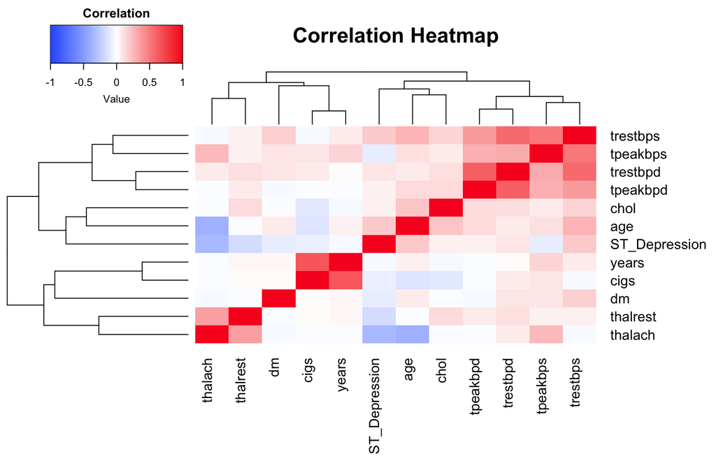

To explore the potential relationship between all the continuous variables, a correlation heatmap was used. This heatmap encompasses the entire set of continuous variables within the dataset, providing a visual representation that accentuates the correlations between these variables. Ranging from strongly negative to strongly positive, the correlations are vividly illustrated. Specifically, the variable `trestbps`, which denotes the resting blood pressure of the patient, exhibits varying degrees of correlation with each variable across the map. Notably, the strength of these correlations intensifies as we traverse further to the right and upper portions of the map, while it diminishes in a negative direction towards the left and lower regions.

Distribution of Data

|  | age | trestbps | chol | cigs | years | dm | thalach | thalrest | tpeakbps | tpeakbpd | trestbpd | ST_Depression |
| --- | --- | --- | --- | --- | --- | --- | --- | --- | --- | --- | --- | --- |
|  | Min. :29.00 | Min. : 94.0 | Min. :126.0 | Min. :-9.00 | Min. :-9.00 | Min. :1.000 | Min. : 71.0 | Min. : 40.00 | Min. : 84.0 | Min. : 26.00 | Min. : 50.00 | Min. :0.000 |
|  | 1st Qu.:48.00 | 1st Qu.:120.0 | 1st Qu.:213.0 | 1st Qu.: 0.00 | 1st Qu.: 0.00 | 1st Qu.:1.000 | 1st Qu.:133.2 | 1st Qu.: 65.00 | 1st Qu.:154.0 | 1st Qu.: 70.00 | 1st Qu.: 80.00 | 1st Qu.:0.000 |
|  | Median :55.00 | Median :130.0 | Median :244.0 | Median :10.00 | Median :15.00 | Median :1.000 | Median :153.5 | Median : 74.00 | Median :168.0 | Median : 80.00 | Median : 85.00 | Median :0.800 |
|  | Mean :54.41 | Mean :131.6 | Mean :249.1 | Mean :16.46 | Mean :14.83 | Mean :1.082 | Mean :149.8 | Mean : 75.12 | Mean :168.1 | Mean : 78.74 | Mean : 84.95 | Mean :1.027 |
|  | 3rd Qu.:61.00 | 3rd Qu.:140.0 | 3rd Qu.:277.0 | 3rd Qu.:30.00 | 3rd Qu.:30.00 | 3rd Qu.:1.000 | 3rd Qu.:165.8 | 3rd Qu.: 84.00 | 3rd Qu.:184.0 | 3rd Qu.: 85.00 | 3rd Qu.: 90.00 | 3rd Qu.:1.600 |
|  | Max. :77.00 | Max. :200.0 | Max. :564.0 | Max. :99.00 | Max. :54.00 | Max. :2.000 | Max. :202.0 | Max. :119.00 | Max. :232.0 | Max. :120.00 | Max. :110.00 | Max. :6.200 |

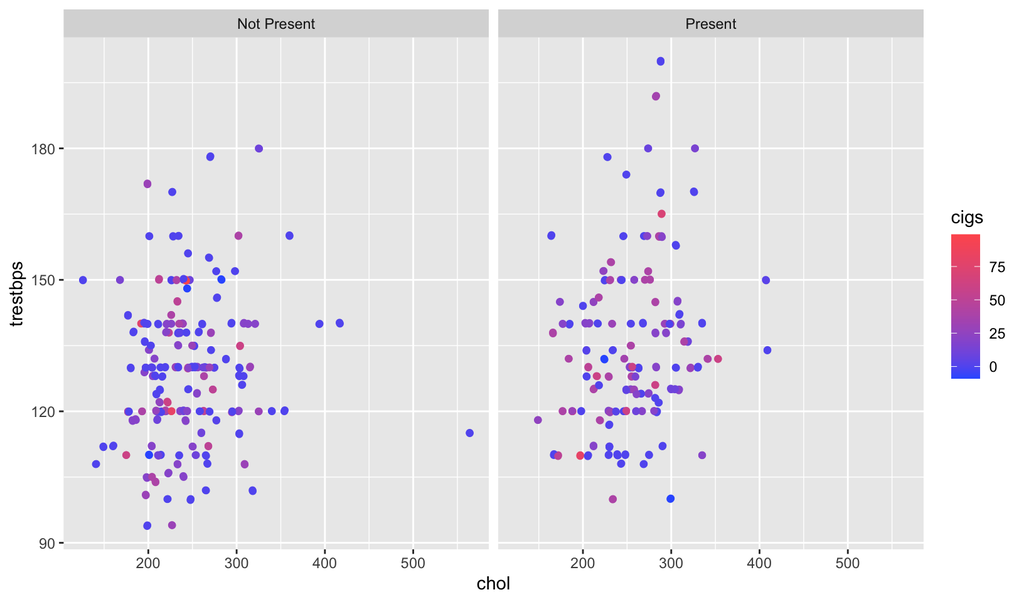

While the table shows the distribution of the overall data, we took three variables that CDC outlined as the major biomarkers. In the graph, the variables that CDC outlined as the top three main risk factors to heart disease. Plotting cholesterol (`chol`) on the x-axis, resting blood pressure (`trestbps`), and create two scatter plots according to the presence of heart disease with each point color coded to represent the number of cigarettes per day (`cigs`), a clear visual of how the data is distributed is presented. Creating two figures based on the following variables: one of patients with Heart Disease and one of patients without Heart Disease revealed there is no clear correlation or difference between these two figures we created. Patients with Heart Disease present tended to have higher resting blood pressure values but besides that the data is similarly distributed suggesting these variables might not be as correlated with Heart Disease as the CDC would suggest.

# **RESULTS**

### **Question 1: Identifying the Optimal Variables for Predicting Heart Disease in Patients**

Accuracy of Logistic Model Results

|  | Predicted Negative | Predicted Positive | Total |
| --- | --- | --- | --- |
| Actual Negative | 27 | 6 | 33 |
| Actual Positive | 5 | 18 | 23 |
| Total | 32 | 24 | 56 |

Metrics

|  | Accuracy | Precision | Recall | F1 |
| --- | --- | --- | --- | --- |
| Accuracy | 0.8035714 | 0.8181818 | 0.84375 | 0.8307692 |

Accuracy of KNN Model

|  | Predicted Negative | Predicted Positive | Total |
| --- | --- | --- | --- |
| Actual Negative | 26 | 8 | 34 |
| Actual Positive | 6 | 16 | 22 |
| Total | 32 | 24 | 56 |

Metrics

|  | Accuracy | Precision | Recall | F1 |
| --- | --- | --- | --- | --- |
| Accuracy | 0.75 | 0.7647059 | 0.8125 | 0.7878788 |

[figure not shown]

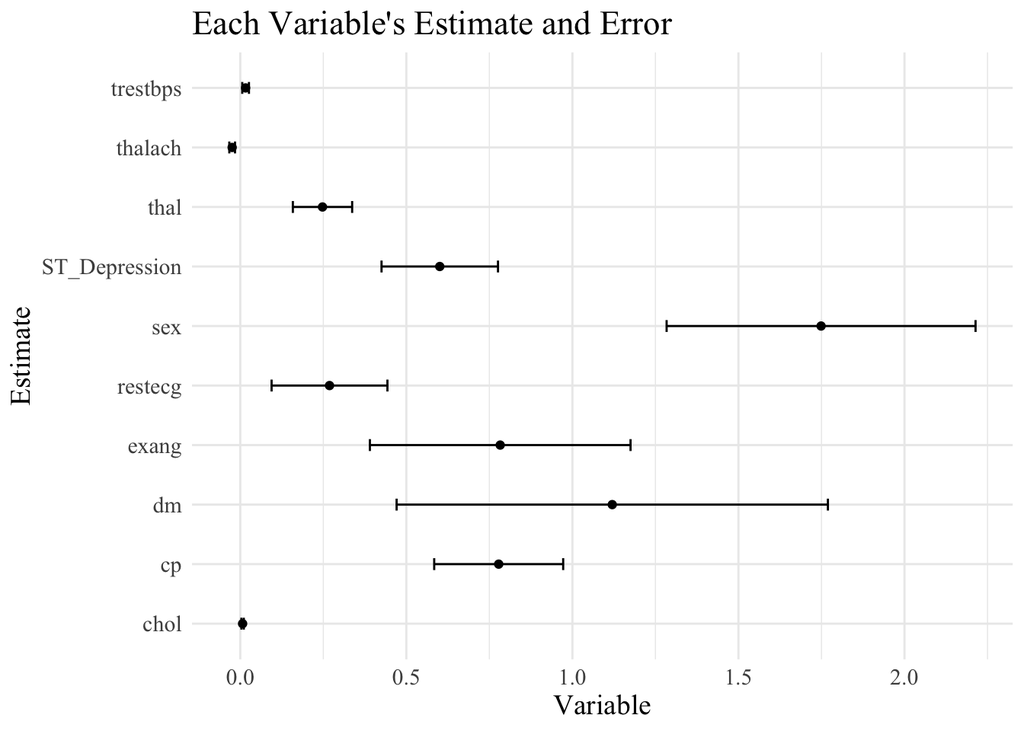

The graph above shows the coefficients and standard error for the model found through stepwise regression for each variable selected. By utilizing a error bar graph, a visualization of how precise the measurement between each variable to predicting the presence of heart disease. In other words, we are observing how far from the reported value the true value may be. Variables that have the smallest error bars include resting blood pressure (`trestbps`), maximum heart rate (`thalach`), and cholesterol (`chol`) which are three of the biological markers that were outlined by CDC to be three of the more common signs to heart disease. There is statistical proof that shows that these biological factors are aspects that could be used. The reason as to why these related to heart disease is because elevated cholesterol could cause blood vessels on be constricted. Elevated cholesterol would cause deposits, such as plaque, into the blood stream, blocking the blood vessels and proper blood flow. With restricted blood flow, it could also result in higher blood pressure due to the extra force needed to pump the blood through the blood steam. It could also cause constriction of the arteries in the heart, which would also force the heart to pump harder. The faster and forceful pump would translate over to higher maximum heart rate.

### **Question 2: Exploring Key Factors Influencing the Accuracy of Predicting Heart Disease Stages in Patients**

Metrics

|  | Accuracy | Kappa |
| --- | --- | --- |
| Random Forest | 0.6117647 | 0.3245846 |
| Ordinal Classfication | 0.5882353 | 0.3173474 |

This table is analyzing our random forest model versus our ordinal classification model. The accuracy for our random forest model is 0.61 while the accuracy for our ordinal classification model is 0.59. Kappa is a metric designed to analyze the inter-rater reliability for categorical variables. Our random forest model kappa was 0.32 while for our ordinal classification model it was also 0.32. This means that both models are considered “fair” in terms of inter-rater reliability which is not the best and could definitely be improved.

[figure not shown]

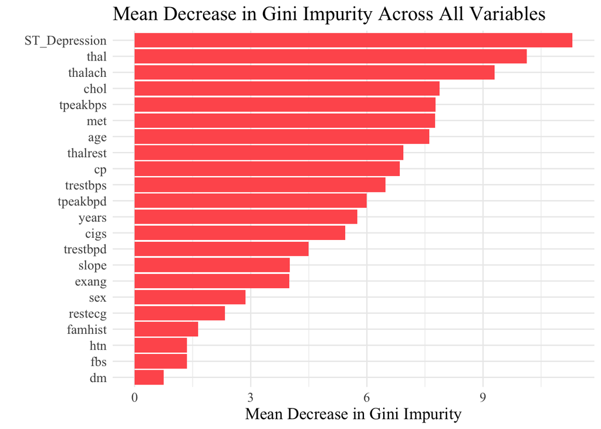

Random forests or Random Decision Forest is a type of machine learning algorithm used for classification, regression and other tasks. We have used it to create a figure analyzing the mean decrease in gini impurity. Gini impurity is used to build decision trees and we used it to determine what variables are most important for accurately predicting heart disease. A gini impurity of 0 is the lowest and best possible impurity because it would represent that our model correctly predicted the presence of heart disease for each patient for that specific tree. The Mean Decrease in Gini Impurity serves as the pivotal metric for gauging the significance of individual variables in enhancing the precision of heart disease stage predictions. This coefficient reflects how each variable influences the homogeneity of nodes and leaves within the resulting random forest. The greater the Mean Decrease in Accuracy or Mean Decrease Gini score, the more pivotal the role of the variable in the overall model, emphasizing its heightened importance and the reason we choose to use this as our measurement. Therefore, a higher decrease in the mean gini impurity would represent a variable that is predicting better with the random forest model compared to the ordinal classification model. This allows us to decide what variables are most important for predicting the presence of heart disease because they will have a higher decrease in gini impurity and therefore be a better predictor. An important limitation to note however is that gini impurity can be highly biased in favor of variables with many possible split points.

Based on the figure above we see that the top four variables for predicting whether or not a patient has heart disease are `ST_Depression`, `thal`, `chol`, and `thalach`. Due to these variables all having lower gini impurities within the random forest model compared to the ordinal classification model. While we see that the variables `dm`, `fbs`, `htn`, `famhist`, and `restecg` gini impurities in the random forest model are relatively similar to the ordinal classification model and therefore are not as important for predicting heart disease within a patient. We can therefore answer our question using the Mean Decrease in Gini Impurities because as shown by our model the best predictors for predicting Heart Disease are `ST_Depression`, `thal` `chol`, and `thalach`. While the variables `dm`, `fbs`, `htn`, `famhist`, and `restecg` are some of the worst predictors for predicting Heart Disease.

# **CONCLUSION**

In our study, we sought to identify key factors that contribute to the onset and progression of heart disease. Using metrics such as logistic regression and random forest models, we analyzed a myriad of variables derived from real-world patient data ranging from demographic information to medical indicators. Our findings revealed significant predictors of heart disease such as sex, chest pain type, cholesterol levels, diabetes, and specific ECG readings like ST depression and maximum heart rate. These results, while aligning with already understood medical understandings, also offered new insights into heart disease, specifically the relationships between various factors and heart disease.

There are several future directions and improvements for our modeling of heart disease. While thorough in the data, integrating more diverse data types could enhance its accuracy and bring forth even better predictor variables. For instance, insights into hereditary genetic factors and family health history could better the accuracy of the model. Additionally, lifestyle data, including diet, physical activity, and stress levels could offer a more holistic view of risk factors. More complex machine learning models could be applied to this data that are more adept at illustrating complex, non-linear relationships in the data that our logistic regression and random forest models could not show. In addition, multi-method models could be used to enhance accuracy in predictions that go beyond our study. Ideally, models like this could be more personalized and precise allowing enhanced medicinal approaches. By tailoring models to an individual’s characteristics, we might be better able to predict heart disease more accurately for many different subgroups of the population.

The real-world implications of our findings are significant. For healthcare professionals, these insights can provide a more refined lens to view and evaluate a patient’s heart disease risk which can, in turn, enhance diagnostic accuracy and improve patient care. These findings can also lead to more informed public health strategies that can be used in preventative measures. Understanding the interconnectedness of these factors that contribute to heart disease can allow for more effective measures. For example, emphasizing the increased risk in men and stressing the importance of reporting their heart pain could lead to earlier diagnoses and better patient outcomes. This knowledge can also guide resource allocation, which can ensure that funds and efforts are directed toward the most impactful treatments. Beyond healthcare and public policy, the study’s implications can broadened to be impact society as a whole. By reducing the incidence and improving the management of heart disease there can be an overall impact on humanity. Communities with better heart health can experience a reduction in healthcare costs, increased productivity, and overall improved quality of life.